# Projet 4 - MOOC

```
                                    _ _Sondra, Franck, Ali_ _
```

## Présentation du sujet

- Récupération & analyse des données de forum Fun MOOC et EdX
- Générer des graphiques qualitatifs sur les informations de fils de discution de forum MOOC FUN/EdX

## Motivation et objectif global

### Demandes initiale

- Lire les fichiers (à partir du site)
- Identifier leur contenu et les informations disponibles
- Extraire de l’information : username, thread_type, cours, body, etc.
- Aider à la conception des bases de données
- Comprendre et s’approprier les données
- Faire une description statistique(résumé, indicateur, comptage, etc.)
- Faire une description graphique(histogramme, barplot, pieplot, etc.)

### Nouvelle demandes

- Ajouter la taille cumulée et moyenne : – = longueur du body du message – + longueur des body des childs
- Identifier les messages / fils de discussion les plus ‘verbeux’
- Faire une description graphique (histogramme, barplot, pieplot, etc.)
- Les votes : les plus populaires ?

Note : tester archive AR, BZ2, RAR, JAR, WAR, TGZ, TXT...

## Projet : Objectif

Visualiser pour un cours :

- Les contributeurs les plus actifs (pareto)
- Répartition des messages dans le temps
- Répartition par groupes (topics)
- Comparer des cours entre eux
- Les plus actifs, les plus longs ...

### Organisation

Les équipes projet :

- Projet modulaire
- Scrum
- Git
- Arbres de compétences

### Outils

Codage Suite:

- python (Spyder)
- R (RStudio)
- SQL (PostgreSQL)
- noSQL (Mongo DB, Mongo Compass)

### Les données

A récupérer sur les sites...

- Authentification
- Format : JSON
- ZIP archives disponibles
- Mettre dans des bases noSQL (mongo)
- Configuration BDD / groupe (R/W), ‘team’ en lecture (R)
- Pas de récup si thread déjà extrait

### Les BDD

- MongoDB -- Créer les BDD avec les bon droits d’accès -- Les requètes -- D’optimisation
- Elasticsearch – mise à disposition (pas utiliser par notre équipe)
- Les archives - Récupérer des données dans des formats divers

### Traitements

Traitements statistiques des infos

- En R
- A partir de BDD SQL (PG)

### Etapes & Compétences associées (cf. référentiel de certification)

Projet 4 « MOOC » : compétences

- Module 1. Concevoir et structurer physiquement une base de données relationnelle ou non.
- Module 2. Acquérir des données, les combiner et les structurer en données propres en vue de leur intégration.
- Module 3. Intégrer des données propres et préparées dans la base de données finale.
- Module 4. Optimiser une base de données afin d’en maintenir la fiabilité et la qualité des données.
- Module 5. Interroger la base de données afin de mettre à jour les données stockées, en fonction du résultat recherché.
- Module 6. Concevoir et réaliser un rendu visuel des données issues du processus d'extraction.
- Module 7. Mettre à disposition les rendus visuels et physiques des données.
- Module 8. Analyser et formaliser le besoin en développement et en exploitation de base de données.
- Module 9. Autocontrôler, la cohérence des données et la conformité à la demande.
- Module 11. Rendre compte de l’avancement du projet.
- Module 12. Rechercher des solutions pour la résolution de problèmes

### Dispositif d’évaluation

Livrables :

- Des BDD contenant les données MOOC (noSQL et SQL)
- Des statistiques qualitatives (notebook R typiquement) concernant les forums de MOOC

Bonus :

- Textmining

### Les limites du sujet

Travail toujour à finir ou faire!!!!

Finir

- Boule des zips

à Faire

- Maîtrise du pipeline & map-reduce
- Obtenir des données (json) d’autres cours

## --------------------------------------------------------------------------------------------------------------------------------

# Tâches à faire

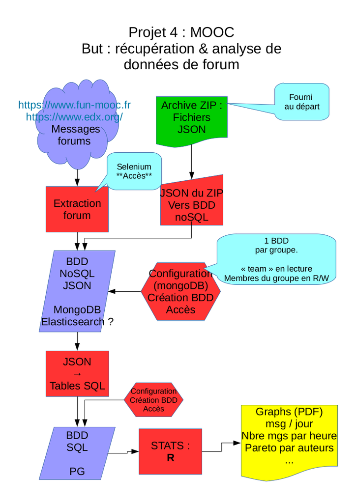

# Le contenu des données

Introduction to Project Management 6 weeks (Anglais)

- course-v1:AdelaideX+Project101x+2T2016 date du 15-07-2016 au 17-03-2017
- Adelaide University en partenaire avec EdX

Du manager agile au leader designer / From an agile manager to a designer leader - 5 semaine session 5 (Français et Anglais)

- CNAM/01002/Trimestre_1_2014 date du 03-02-2014 au 15-05-2014
- Le CNAM

S'initier à la fabrication numérique - 4 semaine -session5

- course-v1:MinesTelecom+04026+session05 du 17 sep 2019 au 05 nov 2019
- L'Institut Mines-Télécom

Introduction à la statistique avec R -Session 12

- course-v1:UPSUD+42001+session12 du 09 sep 2019 au 20 oct 2019
- L'Université Paris-Sud

Python 3 : des fondamentaux aux concepts avancés du language

- course = "course-v1:UCA+107001+session02" 17 sep 2018 au 06 sep 2020
- L'Université Côte d'Azur

### ------------------------------------------------------------------------------------------------------------------------------------

## 1er étape: Configurations

### Configuration des BDD

Configuration BDD / groupe (R/W), ‘team’ en lecture (R)

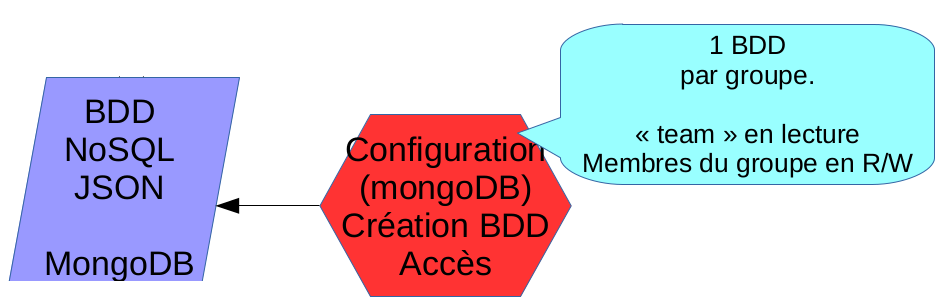

#### 1. Creation de groupe par admin - MongDB

db.grantRolesToUser

- [{ role: "dbOwner", db: "MOOC_GRP_AFS" } ]
- [{ role: "readWrite", db: "MOOC_GRP_AFS" }]

# -----------------------------------------------------------------------------------------------

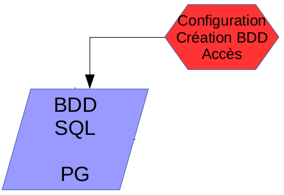

#### 2. Creation de groupe par admin - PostgreSQL

- GRANT ALL ON TABLE public."Fun_Mooc" TO owner;
- GRANT SELECT, UPDATE, INSERT ON TABLE public."Fun_Mooc" TO "GRP_AFS";

### ------------------------------------------------------------------------------------------------------------------------------------

### Importation des archives en zip - Python

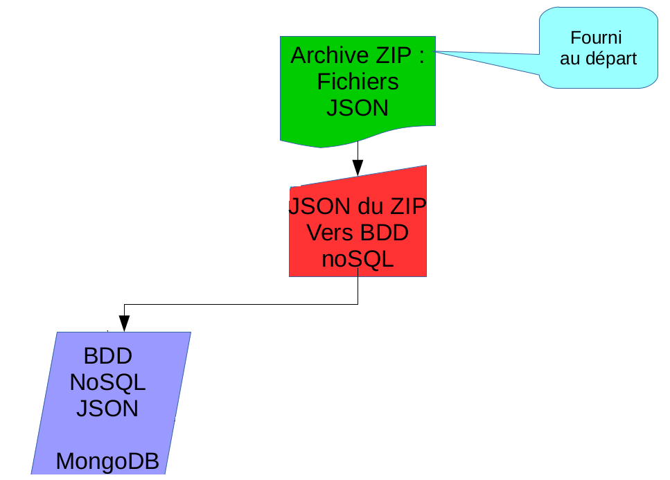

### Ajouter en MongoDB la collection des archives en zip

- quatre fichiers zip avec "zipfile"
- une fichier 7zip avec "libarchive"

## ------------------------------------------------------------------------------------------------------------

## 2ème étape: Le code de Python

### Importation des json à partir des sites - Python

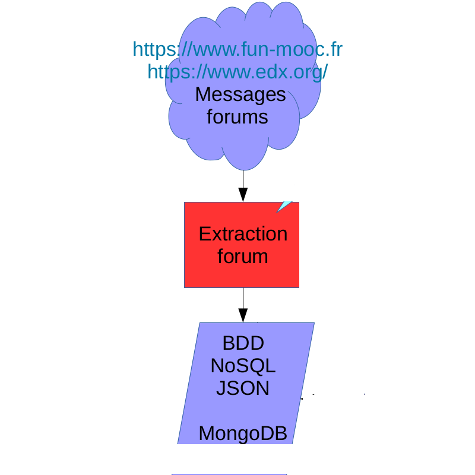

[figure not shown]

### ------------------------------------------------------------------------------------------------------------------------------------

### Les requêtes de MongoDB - R

Pour faire l'anaylses des données récupérer nous faisons les fonctions de requêtes de MongoDB avec mongolite dans RStudio, telles que :

- iterate
- aggregate

Les informations que nous avons décidés de récupérer sont:

- id (character)
- course_id (character)
- courseware_title (character)
- date (Timestamp)
- user_id (character)
- username (character)
- title (character)
- body (character)
- resp_total (integer)
- thread_type (character)
- mtype (character)
- thread_id (character)
- parent_id (character)
- endorsed (character)

Nous ajoutons aussi le calcul fait en python pour la longueur du message (body):

- blen (integer)

## ------------------------------------------------------------------------------------------------------------

# PostgreSQL

## 3ème étape: Mongo vers PostgreSQL

- Definition de la structure de la base de données
- Determiner les contenus à transferer
- Transfer des contenu necessaires dans une table Postgres

[figure not shown]

### ------------------------------------------------------------------------------------------------------------------------------------

## 4ème étape: Rapports et graphics - PostgreSQL vers RStudio

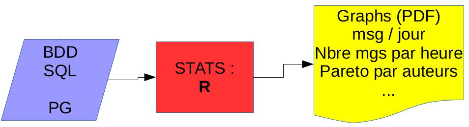

### Première visualisation des données et rapports pour analyser les données.

- Les contributeurs les plus actifs (pareto)
- Répartition des messages dans le temps
- Répartition par groupes (topics)
- Comparer des cours entre eux
- Les plus actifs, les plus longs ...

### Description graphique (histogramme, barplot, pieplot, etc.)

- Ajouter la taille cumulée: – = longueur du body du message – + longueur des body des childs
- Identifier les messages / fils de discussion les plus ‘verbeux’
- Faire une description graphique (histogramme, barplot, pieplot, etc.)

[figure not shown]

1. **MOOC Visualisations_1.0.html**
2. **Textmining_1.0.html**

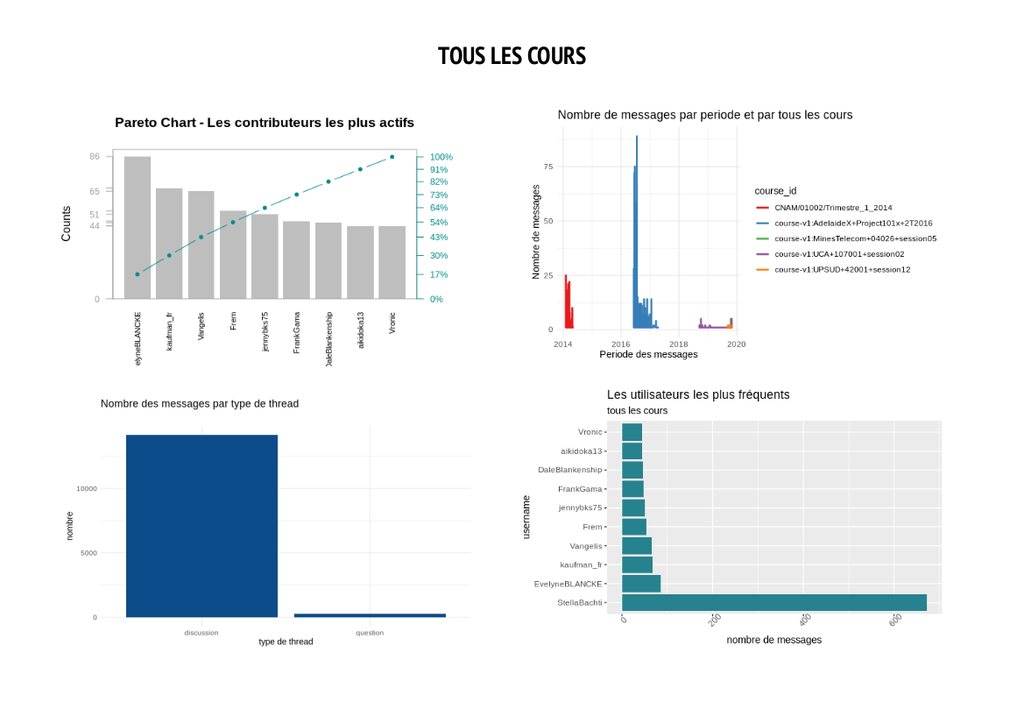

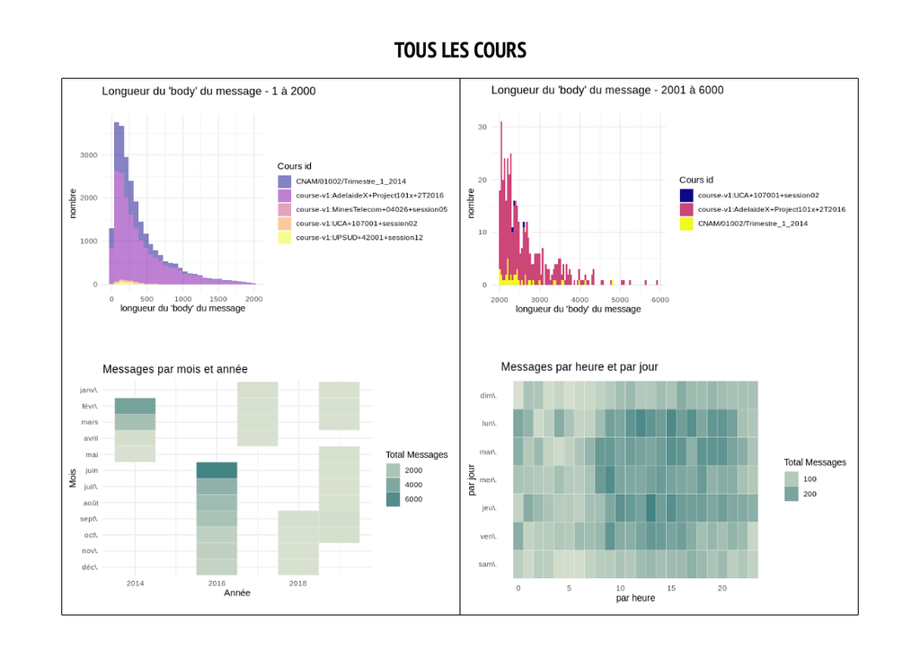

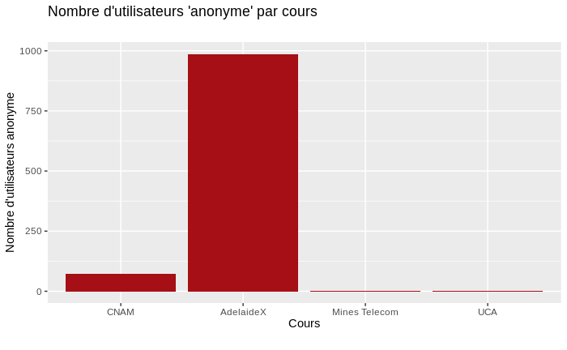

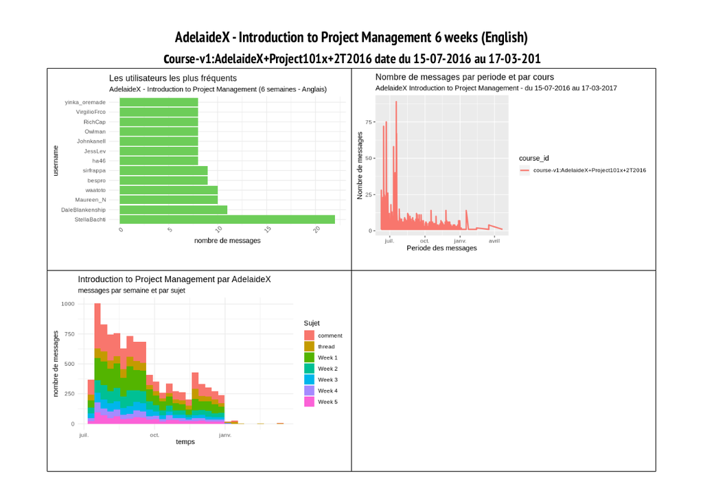

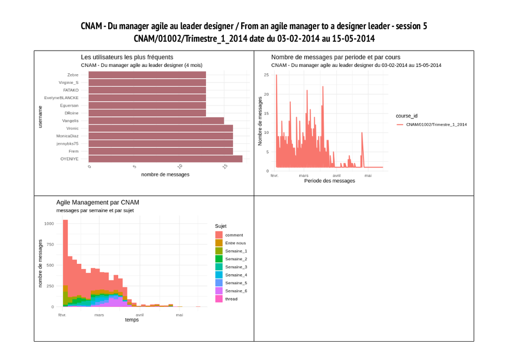

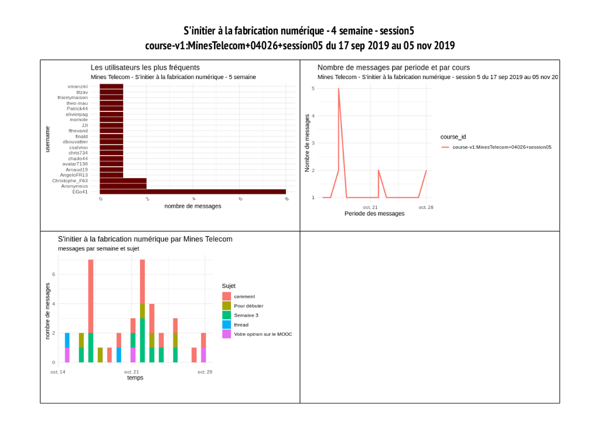

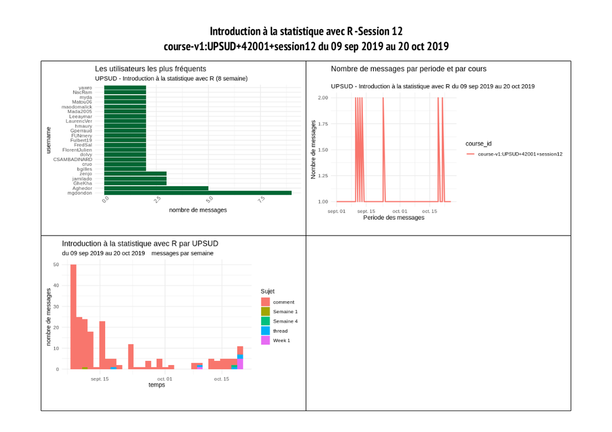

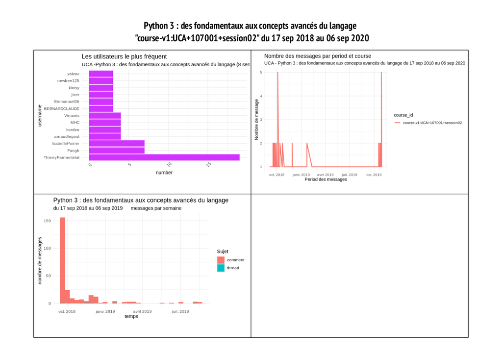

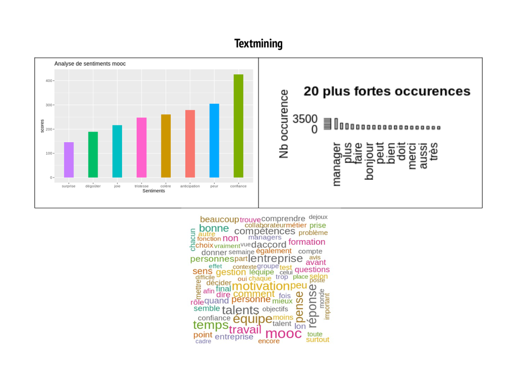

### ------------------------------------------------------------------------------------------------------------------------------------

# Problèmes et perspectives

## 5ème étape: Perspectives d’évolution

- Determiner si les _id crée une issue avec les mises à jours de données
- Un systeme de gestion des erreurs pour auto apprentissage fort et clair
- Codage de correction automatique des erreurs

## Problèmes rencontrés

### Problèmes résolus

- En R conversion des dates en char (json) au format date RStudio.
- Récupérer plus d'information dans les children python.
- Récupération sur funMOOC des autres pages.

### ------------------------------------------------------------------------------------------------------------------------------------

## Projet Management (Github)

### Projet Finale

[figure not shown]

### Network Graph

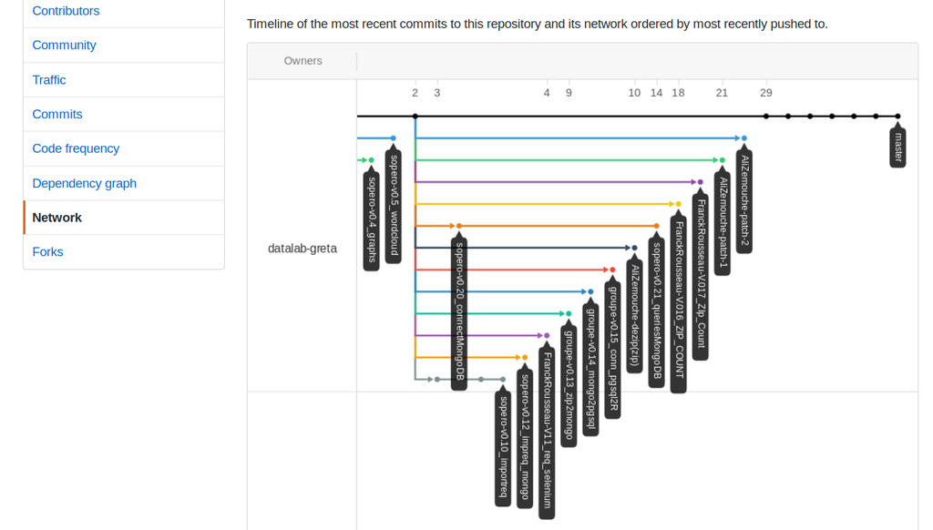

### Rapports

[figure not shown]

[figure not shown]

### ------------------------------------------------------------------------------------------------------------------------------------

# Conclusion

Ce projet nous a permis de travailler sur des bases de données NoSQL et SQL, d'utiliser des compétences déjà aquises lors du web scraping et PostgreSQL. Cela nous a permis de voir les problèmes liés aux archives, projet très intéressant.

## Perspectives personnelles

Franck, Ali, Sondra